# Telecom Customer Clustering

## The k-means elbow plot

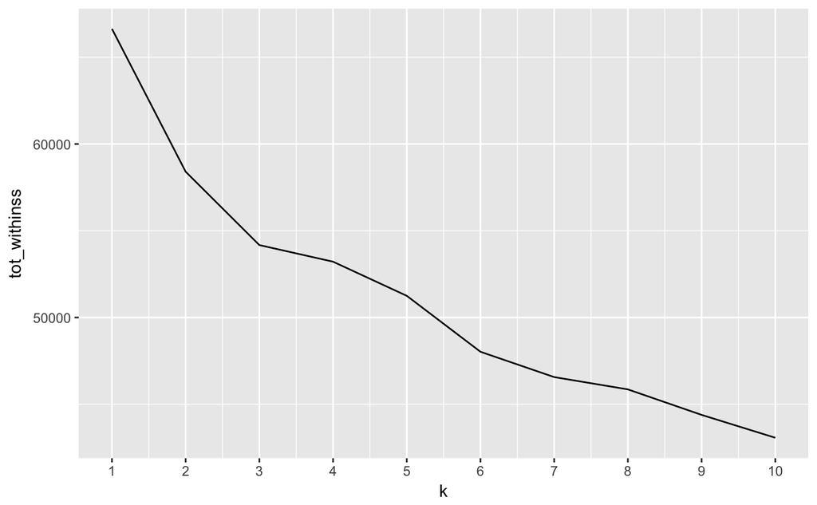

```r
tot_withinss<-map_dbl(1:10, function(k) {
  model<-kmeans(scale(customer1),centers = k)
  model$tot.withinss
})
elbow_df<-data.frame(
  k=1:10,
  tot_withinss=tot_withinss
)
ggplot(elbow_df,aes(x=k,y=tot_withinss)) +
  geom_line() +
  scale_x_continuous(breaks=1:10)
```

## Average silhouette widths

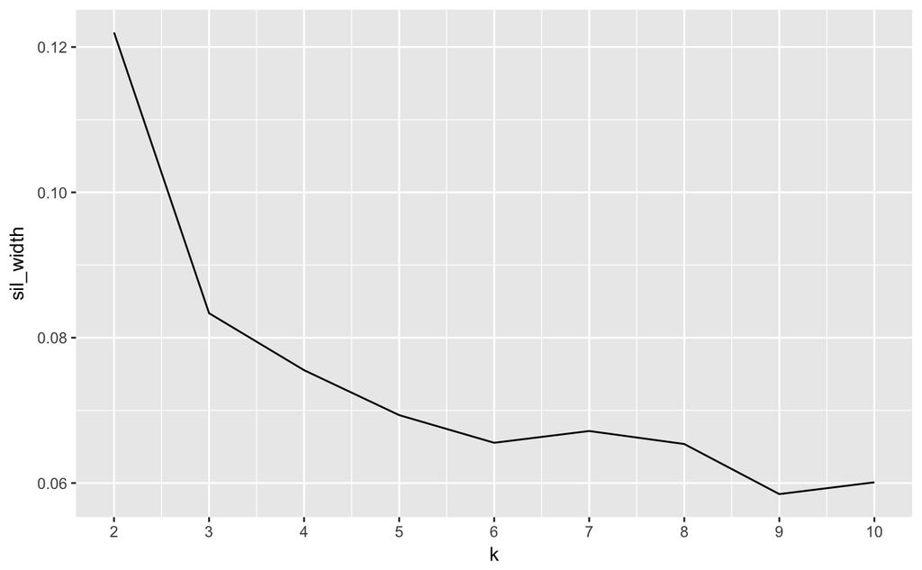

```r
sil_width<-map_dbl(2:10, function(k){
  model<-pam(scale(customer1[,-18]), k = k)
  model$silinfo$avg.width
})
sil_df<-data.frame(
  k=2:10,
  sil_width=sil_width
)
ggplot(sil_df,aes(x=k,y=sil_width))+
  geom_line() +
  scale_x_continuous(breaks = 2:10)
```

# K-means clustering with the optimal k of 2

```r
customer.km<-kmeans(scale(customer1), centers = 2, nstart = 20)
customer1$kmeans<-customer.km$cluster
customer1 %>%
  group_by(kmeans)%>%
  summarise_all(funs(mean(.)))
```

| kmeans | Account Length | Int'l Plan | VMail Plan | VMail Message | Day Mins | Day Calls | Day Charge | Eve Mins | Eve Calls | Eve Charge | Night Mins | Night Calls | Night Charge | Intl Mins | Intl Calls | Intl Charge | CustServ Calls | TotalMin | TotalCalls | TotalCharge |
| --- | --- | --- | --- | --- | --- | --- | --- | --- | --- | --- | --- | --- | --- | --- | --- | --- | --- | --- | --- | --- |
| 1 | 100.8182 | 0.0869826 | 0.2783443 | 8.023395 | 146.0339 | 100.3767 | 24.82629 | 179.5433 | 100.1698 | 15.26137 | 187.1373 | 99.63107 | 8.421278 | 10.26845 | 4.442112 | 2.772999 | 1.638872 | 522.9829 | 304.6197 | 51.28194 |
| 2 | 101.3115 | 0.1068427 | 0.2749100 | 8.174670 | 213.5366 | 100.4946 | 36.30176 | 222.4303 | 100.0588 | 18.90680 | 214.6151 | 100.58463 | 9.657743 | 10.20612 | 4.516807 | 2.756158 | 1.486795 | 660.7880 | 305.6549 | 67.62247 |

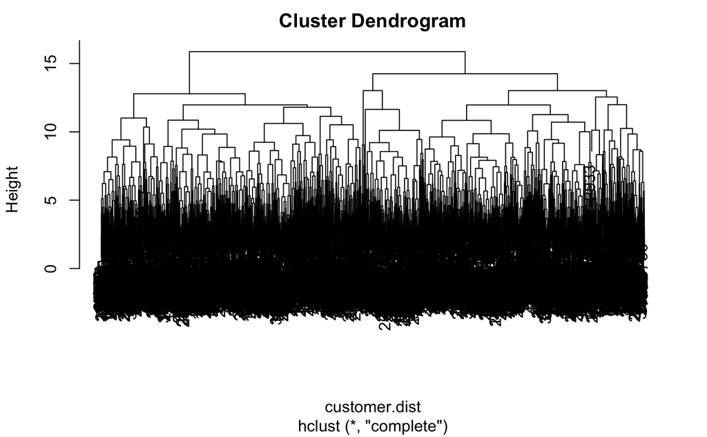

```r
customer.dist<-dist(scale(customer1))
customer.hclust<-hclust(customer.dist,method = "complete")
plot(customer.hclust)
```

```r
customer.hclust.cluser<-cutree(customer.hclust,k=2)
customer1$hierarchical<-customer.hclust.cluser
customer1 %>%
  group_by(hierarchical) %>%
  summarise_all(funs(mean(.)))
```

| hierarchical | Account Length | Int'l Plan | VMail Plan | VMail Message | Day Mins | Day Calls | Day Charge | Eve Mins | Eve Calls | Eve Charge | Night Mins | Night Calls | Night Charge | Intl Mins | Intl Calls | Intl Charge | CustServ Calls | TotalMin | TotalCalls | TotalCharge | kmeans |
| --- | --- | --- | --- | --- | --- | --- | --- | --- | --- | --- | --- | --- | --- | --- | --- | --- | --- | --- | --- | --- | --- |
| 1 | 100.8310 | 0.1076345 | 0.3103880 | 9.138298 | 211.1058 | 100.2134 | 35.88856 | 222.9469 | 99.75219 | 18.95070 | 214.2590 | 100.75469 | 9.641702 | 10.10907 | 4.401752 | 2.729931 | 1.490613 | 658.4208 | 305.122 | 67.21089 | 1.947434 |
| 2 | 101.2801 | 0.0870317 | 0.2455331 | 7.141787 | 150.9184 | 100.6403 | 25.65663 | 180.7483 | 100.44784 | 15.36382 | 188.5421 | 99.51182 | 8.484513 | 10.35539 | 4.551009 | 2.796496 | 1.629395 | 530.5642 | 305.151 | 52.30145 | 1.087608 |

# Conclusion

For K-mean: Cluster 1(Unhappy and less frequent servies used customers): Lower total mins and call with higher Service calls Cluster 2(Frequent and Active service customers): Higher total mins and total charge

For Hierarchical: Cluster 1: Higher min, charge and less service call Cluster 2: Tend to have shorter min of calls, more service call

There is no right or wrong question. It will be tailored down to the business needs and requirements.

# Future Work

Couple things I could tackle are: 1. PCA 2. Feature Engineering